# ME - GIA. Introduccio MLGz (Factors)

2024-09-17

## Introducció

En l’elaboració de formatges, el rendiment és la relació entre el pes del formatge obtingut i el de la llet utilitzada. Es vol veure, per separat en llet de **ovella i de vaca**; com canvia el rendiment amb un tractament tèrmic (**crua/pasteuritzada**) i amb l’addició de CaCl2 (**si/no**). Les dades són al fitxer `formatges.csv`. Per cadascun dels tipus de llet per separat, ajustarem un model lineal generalitzat.

En aquest document, veurem:

- Per la llet de vaca, necessitem el model **factorial** (amb interacció)
- Per la llet de ovella, ens serveix el model **additiu** (sense interacció)

Aspectes previs: Directori, Paquets, Llegir dades, definir variables, factors …

```r
# Carregar llibreries
library(tables)   # tabular
library(emmeans)  # emmeans
library(car)      # residualPlot
library(RcmdrMisc)#
library(multcomp) # cld

# Llegir dades
dd <- read.csv2("../Dades/formatges.csv", stringsAsFactors = TRUE)
```

## Llet de vaca

### Descriptiva

Les següents taules, mostren la *n*, la *mitjana* i la *desviació estàndard* per cada combinació de nivells.

```r
print(tabular((n=1) * VACA * (TERMIC+1) ~ (CaCl2+1), dd),html=FALSE) # n
```

```
##
##                       CaCl2
##         TERMIC        amb   sense All
##  n VACA crua          4     4      8
##         pasteuritzada 4     4      8
##         All           8     8     16
```

```r
print(tabular( mean * VACA * (TERMIC+1) ~ (CaCl2+1), dd),html=FALSE) # mitjana
```

```
##
##                          CaCl2
##            TERMIC        amb   sense All
##  mean VACA crua          39.81 58.56 49.19
##            pasteuritzada 46.00 50.54 48.27
##            All           42.90 54.55 48.73
```

```r
print(tabular(   sd * VACA * (TERMIC+1) ~ (CaCl2+1), dd),html=FALSE) # desv. est.
```

```
##
##                        CaCl2
##          TERMIC        amb   sense All
##  sd VACA crua          4.889 3.556 10.779
##          pasteuritzada 4.279 4.388  4.690
##          All           5.389 5.662  8.044
```

Els següents gràfics mostren la presència d’interacció:

- El que afecta el tipus de llet a la quantitat de formatge depen de si porta CaCl2
- El que afecta el fet d’afegir CaCl2 a la quantitat de formatge depen de si porta tipus de llet

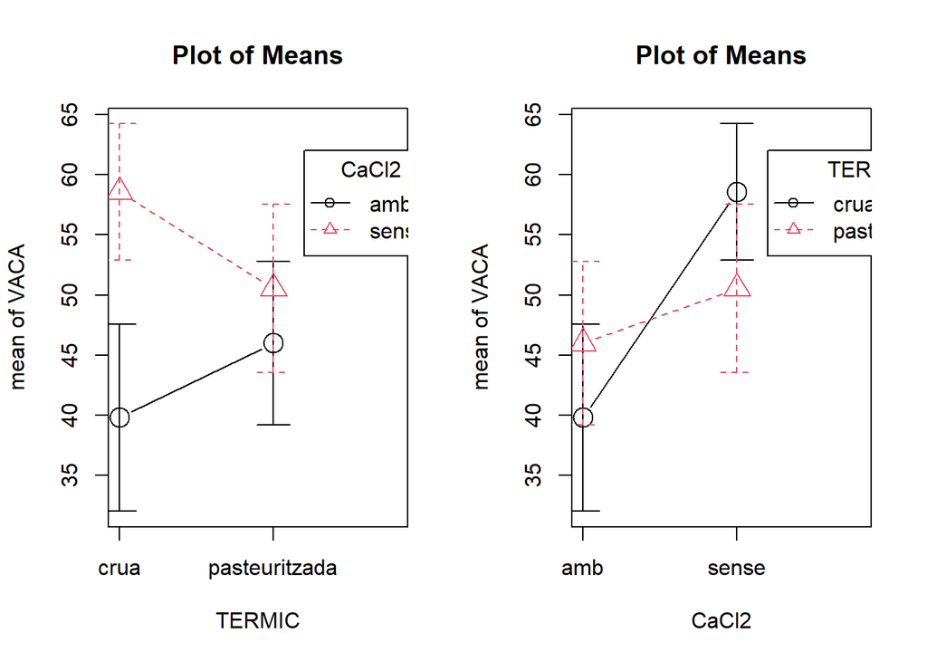

```r
par(mfrow=c(1,2))
with(dd, plotMeans(VACA, TERMIC, CaCl2, error.bars="conf.int", level=0.95, connect=TRUE))
with(dd, plotMeans(VACA, CaCl2, TERMIC, error.bars="conf.int", level=0.95, connect=TRUE))
```

### Ajust model factorial

Ajustem els models factorials amb la família normal i el link canònic (identity).

```r
mv   <-  lm(VACA ~ TERMIC * CaCl2, dd)
mvg  <- glm(VACA ~ TERMIC * CaCl2, dd, family=gaussian)
```

Els dos models són equivalents:

```r
summary(mv)
```

```
##
## Call:
## lm(formula = VACA ~ TERMIC * CaCl2, data = dd)
##
## Residuals:
##     Min      1Q  Median      3Q     Max
## -5.9850 -3.2138  0.1913  2.5437  7.1513
##
## Coefficients:
##                                Estimate Std. Error t value Pr(>|t|)
## (Intercept)                      39.809      2.152  18.496 3.47e-10 ***
## TERMICpasteuritzada               6.191      3.044   2.034  0.06466 .
## CaCl2sense                       18.756      3.044   6.162 4.86e-05 ***
## TERMICpasteuritzada:CaCl2sense  -14.214      4.304  -3.302  0.00632 **
## ---
## Signif. codes:  0 '***' 0.001 '**' 0.01 '*' 0.05 '.' 0.1 ' ' 1
##
## Residual standard error: 4.304 on 12 degrees of freedom
## Multiple R-squared:  0.7709, Adjusted R-squared:  0.7136
## F-statistic: 13.46 on 3 and 12 DF,  p-value: 0.0003799
```

```r
summary(mvg)
```

```
##
## Call:
## glm(formula = VACA ~ TERMIC * CaCl2, family = gaussian, data = dd)
##
## Coefficients:
##                                Estimate Std. Error t value Pr(>|t|)
## (Intercept)                      39.809      2.152  18.496 3.47e-10 ***
## TERMICpasteuritzada               6.191      3.044   2.034  0.06466 .
## CaCl2sense                       18.756      3.044   6.162 4.86e-05 ***
## TERMICpasteuritzada:CaCl2sense  -14.214      4.304  -3.302  0.00632 **
## ---
## Signif. codes:  0 '***' 0.001 '**' 0.01 '*' 0.05 '.' 0.1 ' ' 1
##
## (Dispersion parameter for gaussian family taken to be 18.52841)
##
##     Null deviance: 970.56  on 15  degrees of freedom
## Residual deviance: 222.34  on 12  degrees of freedom
## AIC: 97.512
##
## Number of Fisher Scoring iterations: 2
```

### Interpretació del model

**Resum gràfic del model** (`emmip` del paquet `emmeans`): la interacció és marcada.

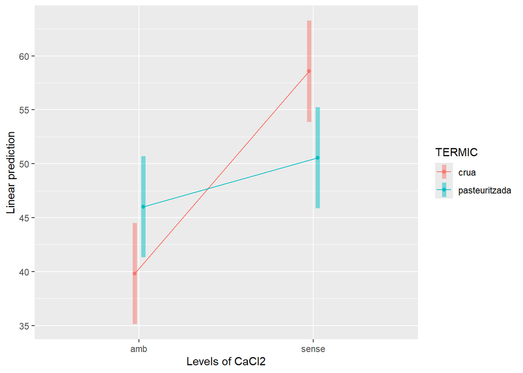

```r
emmip(mvg,TERMIC ~ CaCl2, CIs=T)
```

**Mitjanes marginals** (`emmeans` del paquet `emmeans`)

```r
(emmg <- emmeans(mvg, ~ TERMIC * CaCl2, type = "response"))
```

```
##  TERMIC        CaCl2 emmean   SE df lower.CL upper.CL
##  crua          amb     39.8 2.15 12     35.1     44.5
##  pasteuritzada amb     46.0 2.15 12     41.3     50.7
##  crua          sense   58.6 2.15 12     53.9     63.3
##  pasteuritzada sense   50.5 2.15 12     45.9     55.2
##
## Confidence level used: 0.95
```

```r
(emmc <- emmeans(mvg, ~ TERMIC | CaCl2, type = "response"))
```

```
## CaCl2 = amb:
##  TERMIC        emmean   SE df lower.CL upper.CL
##  crua            39.8 2.15 12     35.1     44.5
##  pasteuritzada   46.0 2.15 12     41.3     50.7
##
## CaCl2 = sense:
##  TERMIC        emmean   SE df lower.CL upper.CL
##  crua            58.6 2.15 12     53.9     63.3
##  pasteuritzada   50.5 2.15 12     45.9     55.2
##
## Confidence level used: 0.95
```

```r
(emmt <- emmeans(mvg, ~ CaCl2  | TERMIC,type = "response"))
```

```
## TERMIC = crua:
##  CaCl2 emmean   SE df lower.CL upper.CL
##  amb     39.8 2.15 12     35.1     44.5
##  sense   58.6 2.15 12     53.9     63.3
##
## TERMIC = pasteuritzada:
##  CaCl2 emmean   SE df lower.CL upper.CL
##  amb     46.0 2.15 12     41.3     50.7
##  sense   50.5 2.15 12     45.9     55.2
##
## Confidence level used: 0.95
```

Comparacions múltiples (`cld` de del paquet `multcomp`):

```r
cld(emmg)
```

```
##  TERMIC        CaCl2 emmean   SE df lower.CL upper.CL .group
##  crua          amb     39.8 2.15 12     35.1     44.5  1
##  pasteuritzada amb     46.0 2.15 12     41.3     50.7  12
##  pasteuritzada sense   50.5 2.15 12     45.9     55.2   23
##  crua          sense   58.6 2.15 12     53.9     63.3    3
##
## Confidence level used: 0.95
## P value adjustment: tukey method for comparing a family of 4 estimates
## significance level used: alpha = 0.05
## NOTE: If two or more means share the same grouping symbol,
##       then we cannot show them to be different.
##       But we also did not show them to be the same.
```

```r
cld(emmc)
```

```
## CaCl2 = amb:
##  TERMIC        emmean   SE df lower.CL upper.CL .group
##  crua            39.8 2.15 12     35.1     44.5  1
##  pasteuritzada   46.0 2.15 12     41.3     50.7  1
##
## CaCl2 = sense:
##  TERMIC        emmean   SE df lower.CL upper.CL .group
##  pasteuritzada   50.5 2.15 12     45.9     55.2  1
##  crua            58.6 2.15 12     53.9     63.3   2
##
## Confidence level used: 0.95
## significance level used: alpha = 0.05
## NOTE: If two or more means share the same grouping symbol,
##       then we cannot show them to be different.
##       But we also did not show them to be the same.
```

### Validació

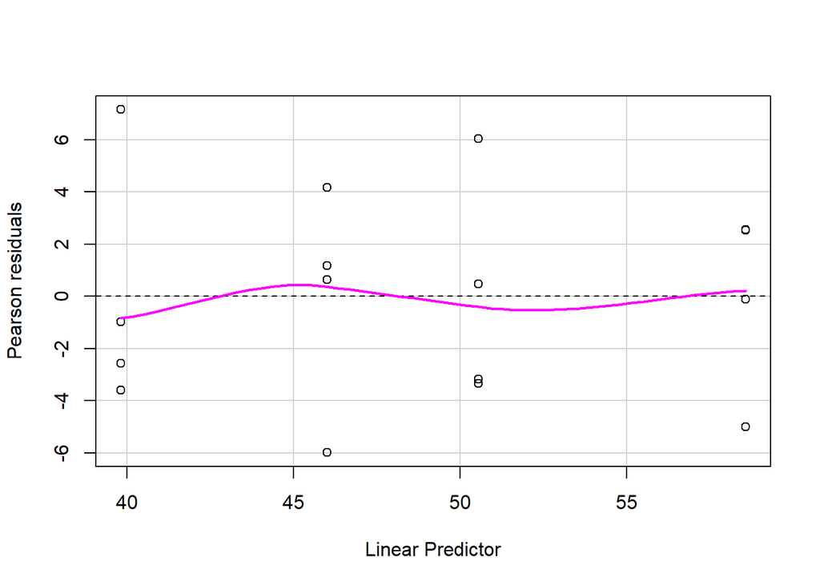

```r
residualPlot(mvg)
```

### Link en el model factorial

Comprovem que canviant el link, el model ajusta igual (ja que és factorial). Per exemple passem del `link=identity` al `link=log`

```r
mvg_log  <- glm(VACA ~ TERMIC*CaCl2, dd, family = gaussian(link=log))
```

Els coeficients, óbviament, canvien:

```r
summary(mvg)
```

```
##
## Call:
## glm(formula = VACA ~ TERMIC * CaCl2, family = gaussian, data = dd)
##
## Coefficients:
##                                Estimate Std. Error t value Pr(>|t|)
## (Intercept)                      39.809      2.152  18.496 3.47e-10 ***
## TERMICpasteuritzada               6.191      3.044   2.034  0.06466 .
## CaCl2sense                       18.756      3.044   6.162 4.86e-05 ***
## TERMICpasteuritzada:CaCl2sense  -14.214      4.304  -3.302  0.00632 **
## ---
## Signif. codes:  0 '***' 0.001 '**' 0.01 '*' 0.05 '.' 0.1 ' ' 1
##
## (Dispersion parameter for gaussian family taken to be 18.52841)
##
##     Null deviance: 970.56  on 15  degrees of freedom
## Residual deviance: 222.34  on 12  degrees of freedom
## AIC: 97.512
##
## Number of Fisher Scoring iterations: 2
```

```r
summary(mvg_log)
```

```
##
## Call:
## glm(formula = VACA ~ TERMIC * CaCl2, family = gaussian(link = log),
##     data = dd)
##
## Coefficients:
##                                Estimate Std. Error t value Pr(>|t|)
## (Intercept)                     3.68409    0.05406  68.143  < 2e-16 ***
## TERMICpasteuritzada             0.14455    0.07150   2.022  0.06608 .
## CaCl2sense                      0.38605    0.06537   5.905 7.19e-05 ***
## TERMICpasteuritzada:CaCl2sense -0.29188    0.09097  -3.208  0.00751 **
## ---
## Signif. codes:  0 '***' 0.001 '**' 0.01 '*' 0.05 '.' 0.1 ' ' 1
##
## (Dispersion parameter for gaussian family taken to be 18.52841)
##
##     Null deviance: 970.56  on 15  degrees of freedom
## Residual deviance: 222.34  on 12  degrees of freedom
## AIC: 97.512
##
## Number of Fisher Scoring iterations: 4
```

Però les estimacions no canvien:

```r
emmeans(mvg,     ~ TERMIC * CaCl2, type='response')
```

```
##  TERMIC        CaCl2 emmean   SE df lower.CL upper.CL
##  crua          amb     39.8 2.15 12     35.1     44.5
##  pasteuritzada amb     46.0 2.15 12     41.3     50.7
##  crua          sense   58.6 2.15 12     53.9     63.3
##  pasteuritzada sense   50.5 2.15 12     45.9     55.2
##
## Confidence level used: 0.95
```

```r
emmeans(mvg_log, ~ TERMIC * CaCl2, type='response')
```

```
##  TERMIC        CaCl2 response   SE df lower.CL upper.CL
##  crua          amb       39.8 2.15 12     35.4     44.8
##  pasteuritzada amb       46.0 2.15 12     41.5     50.9
##  crua          sense     58.6 2.15 12     54.1     63.4
##  pasteuritzada sense     50.5 2.15 12     46.1     55.5
##
## Confidence level used: 0.95
## Intervals are back-transformed from the log scale
```

### Familia en el model factorial

Canviar la família pot afectar a la homoscedasticitat. Per exemple passem de la família Gaussiana a la Inversa Gaussiana mantenint el link identitat.

```r
mvg_iga  <- glm(VACA~TERMIC*CaCl2,family=inverse.gaussian(link=identity),dd)
```

#### Validació

**Gràfic de residus**

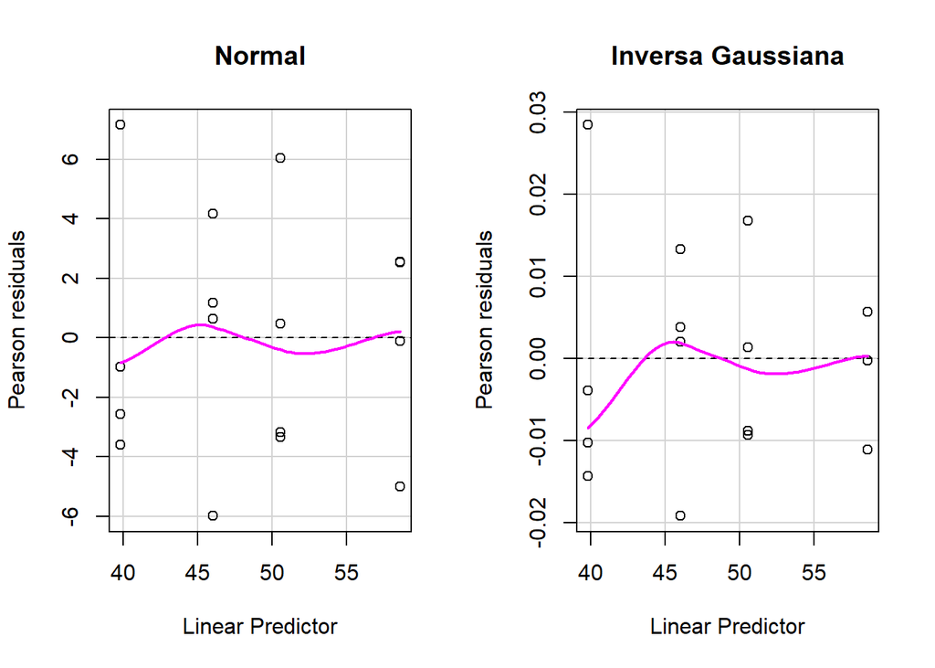

```r
par(mfrow=c(1,2))
residualPlot(mvg,     main = "Normal")
residualPlot(mvg_iga, main = "Inversa Gaussiana")
```

**Homoscedasticitat**

No hi ha diferències signifcatives entre nivells en cap de les 2 families.

```r
# Nivells i residus
dd$levels  <- factor(paste0(dd$TERMIC,'-',dd$CaCl2))
dd$res_nor <- resid(mvg)
dd$res_iga <- resid(mvg_iga)

# Variancies
with(dd,tapply(res_nor, levels, var))
```

```
##            crua-amb          crua-sense   pasteuritzada-amb pasteuritzada-sense
##            23.89992            12.64655            18.31142            19.25574
```

```r
with(dd,tapply(res_iga, levels, var)) * 10^4
```

```
##            crua-amb          crua-sense   pasteuritzada-amb pasteuritzada-sense
##           3.4613466           0.6587509           2.0108208           1.4271519
```

```r
# test var
leveneTest(res_nor ~ levels, dd)
```

```
## Levene's Test for Homogeneity of Variance (center = median)
##       Df F value Pr(>F)
## group  3  0.0465  0.986
##       12
```

```r
leveneTest(res_iga ~ levels, dd)
```

```
## Levene's Test for Homogeneity of Variance (center = median)
##       Df F value Pr(>F)
## group  3   0.254  0.857
##       12
```

## Llet d’ovella

### Descriptiva

Les següents taules, mostren la *n*, la *mitjana* i la *desviació estàndard* per cada combinació de nivells.

```r
print(tabular( mean * OVELLA * (TERMIC+1)~(CaCl2+1),dd),html=FALSE)
```

```
##
##                            CaCl2
##              TERMIC        amb   sense All
##  mean OVELLA crua          52.52 66.64 59.58
##              pasteuritzada 65.48 72.30 68.89
##              All           59.00 69.47 64.24
```

```r
print(tabular(   sd * OVELLA * (TERMIC+1)~(CaCl2+1),dd),html=FALSE)
```

```
##
##                          CaCl2
##            TERMIC        amb   sense All
##  sd OVELLA crua          1.539 9.767 9.940
##            pasteuritzada 4.742 3.396 5.279
##            All           7.655 7.415 9.067
```

```r
print(tabular((n=1) * OVELLA * (TERMIC+1)~(CaCl2+1),dd),html=FALSE)
```

```
##
##                         CaCl2
##           TERMIC        amb   sense All
##  n OVELLA crua          4     4      8
##           pasteuritzada 4     4      8
##           All           8     8     16
```

Els següents gràfics mostren l’absència d’interacció:

- El que afecta el tipus de llet a la quantitat de formatge NO depen de si porta CaCl2
- El que afecta el fet d’afegir CaCl2 a la quantitat de formatge NO depen de si quin tipus de llet porta

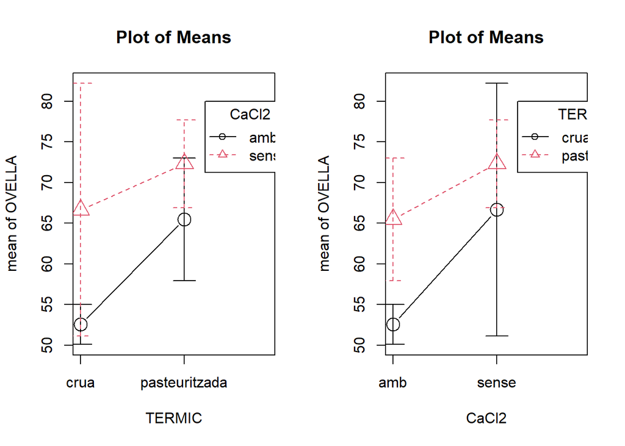

```r
par(mfrow=c(1,2))
with(dd, plotMeans(OVELLA, TERMIC, CaCl2, error.bars="conf.int", level=0.95, connect=TRUE))
with(dd, plotMeans(OVELLA, CaCl2, TERMIC, error.bars="conf.int", level=0.95, connect=TRUE))
```

### Ajust model additiu

Ajustem els models factorials amb la família normal i el link canònic (identity).

```r
mo  <-  lm(OVELLA ~ TERMIC + CaCl2, dd)
mog <- glm(OVELLA ~ TERMIC + CaCl2, family=gaussian,dd)
```

Els dos models són equivalents:

```r
summary(mo)
```

```
##
## Call:
## lm(formula = OVELLA ~ TERMIC + CaCl2, data = dd)
##
## Residuals:
##    Min     1Q Median     3Q    Max
## -7.044 -3.181 -1.205  1.437 11.701
##
## Coefficients:
##                     Estimate Std. Error t value Pr(>|t|)
## (Intercept)           54.348      2.543  21.368 1.65e-11 ***
## TERMICpasteuritzada    9.308      2.937   3.169  0.00739 **
## CaCl2sense            10.466      2.937   3.563  0.00347 **
## ---
## Signif. codes:  0 '***' 0.001 '**' 0.01 '*' 0.05 '.' 0.1 ' ' 1
##
## Residual standard error: 5.874 on 13 degrees of freedom
## Multiple R-squared:  0.6363, Adjusted R-squared:  0.5803
## F-statistic: 11.37 on 2 and 13 DF,  p-value: 0.001396
```

```r
summary(mog)
```

```
##
## Call:
## glm(formula = OVELLA ~ TERMIC + CaCl2, family = gaussian, data = dd)
##
## Coefficients:
##                     Estimate Std. Error t value Pr(>|t|)
## (Intercept)           54.348      2.543  21.368 1.65e-11 ***
## TERMICpasteuritzada    9.308      2.937   3.169  0.00739 **
## CaCl2sense            10.466      2.937   3.563  0.00347 **
## ---
## Signif. codes:  0 '***' 0.001 '**' 0.01 '*' 0.05 '.' 0.1 ' ' 1
##
## (Dispersion parameter for gaussian family taken to be 34.50221)
##
##     Null deviance: 1233.21  on 15  degrees of freedom
## Residual deviance:  448.53  on 13  degrees of freedom
## AIC: 106.74
##
## Number of Fisher Scoring iterations: 2
```

### Interpretació del model

**Resum gràfic del model** (`emmip` del paquet `emmeans`)

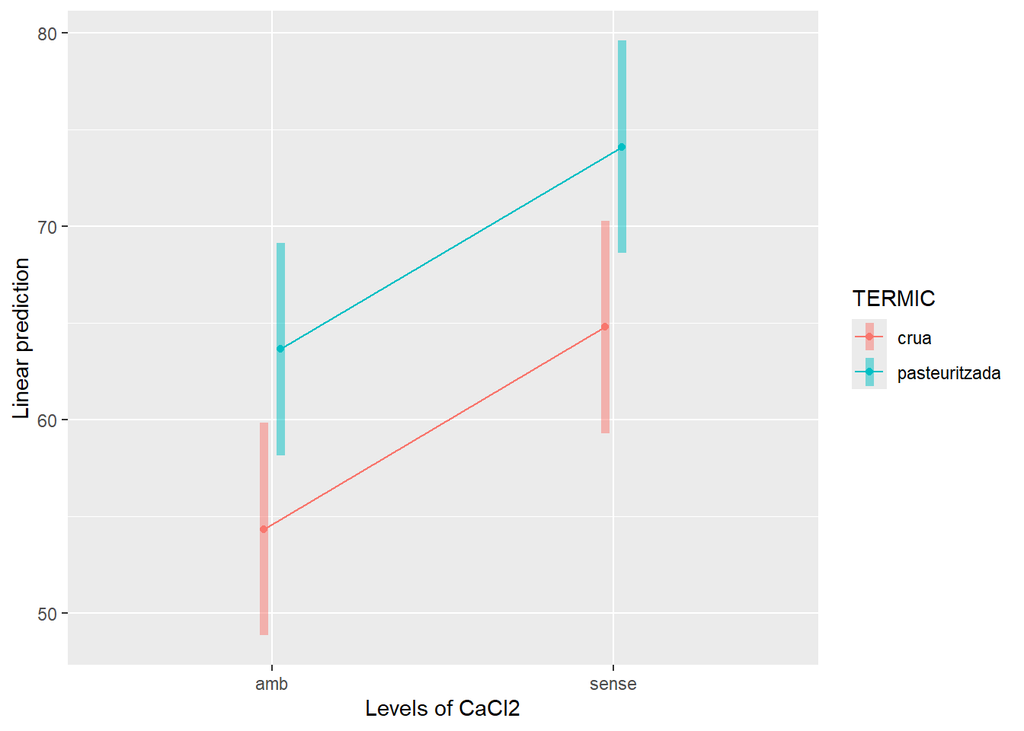

```r
emmip(mog,TERMIC~CaCl2,CIs=T)
```

**Mitjanes marginals** (`emmeans` del paquet `emmeans`)

```r
(emmg <- emmeans(mog, ~TERMIC * CaCl2))
```

```
##  TERMIC        CaCl2 emmean   SE df lower.CL upper.CL
##  crua          amb     54.3 2.54 13     48.9     59.8
##  pasteuritzada amb     63.7 2.54 13     58.2     69.2
##  crua          sense   64.8 2.54 13     59.3     70.3
##  pasteuritzada sense   74.1 2.54 13     68.6     79.6
##
## Confidence level used: 0.95
```

```r
(emmc <- emmeans(mog, ~TERMIC | CaCl2))
```

```
## CaCl2 = amb:
##  TERMIC        emmean   SE df lower.CL upper.CL
##  crua            54.3 2.54 13     48.9     59.8
##  pasteuritzada   63.7 2.54 13     58.2     69.2
##
## CaCl2 = sense:
##  TERMIC        emmean   SE df lower.CL upper.CL
##  crua            64.8 2.54 13     59.3     70.3
##  pasteuritzada   74.1 2.54 13     68.6     79.6
##
## Confidence level used: 0.95
```

```r
(emmt <- emmeans(mog, ~CaCl2  | TERMIC))
```

```
## TERMIC = crua:
##  CaCl2 emmean   SE df lower.CL upper.CL
##  amb     54.3 2.54 13     48.9     59.8
##  sense   64.8 2.54 13     59.3     70.3
##
## TERMIC = pasteuritzada:
##  CaCl2 emmean   SE df lower.CL upper.CL
##  amb     63.7 2.54 13     58.2     69.2
##  sense   74.1 2.54 13     68.6     79.6
##
## Confidence level used: 0.95
```

Comparacions múltiples:

```r
cld(emmg)
```

```
##  TERMIC        CaCl2 emmean   SE df lower.CL upper.CL .group
##  crua          amb     54.3 2.54 13     48.9     59.8  1
##  pasteuritzada amb     63.7 2.54 13     58.2     69.2   2
##  crua          sense   64.8 2.54 13     59.3     70.3   2
##  pasteuritzada sense   74.1 2.54 13     68.6     79.6    3
##
## Confidence level used: 0.95
## P value adjustment: tukey method for comparing a family of 4 estimates
## significance level used: alpha = 0.05
## NOTE: If two or more means share the same grouping symbol,
##       then we cannot show them to be different.
##       But we also did not show them to be the same.
```

```r
cld(emmc)
```

```
## CaCl2 = amb:
##  TERMIC        emmean   SE df lower.CL upper.CL .group
##  crua            54.3 2.54 13     48.9     59.8  1
##  pasteuritzada   63.7 2.54 13     58.2     69.2   2
##
## CaCl2 = sense:
##  TERMIC        emmean   SE df lower.CL upper.CL .group
##  crua            64.8 2.54 13     59.3     70.3  1
##  pasteuritzada   74.1 2.54 13     68.6     79.6   2
##
## Confidence level used: 0.95
## significance level used: alpha = 0.05
## NOTE: If two or more means share the same grouping symbol,
##       then we cannot show them to be different.
##       But we also did not show them to be the same.
```

### Validació

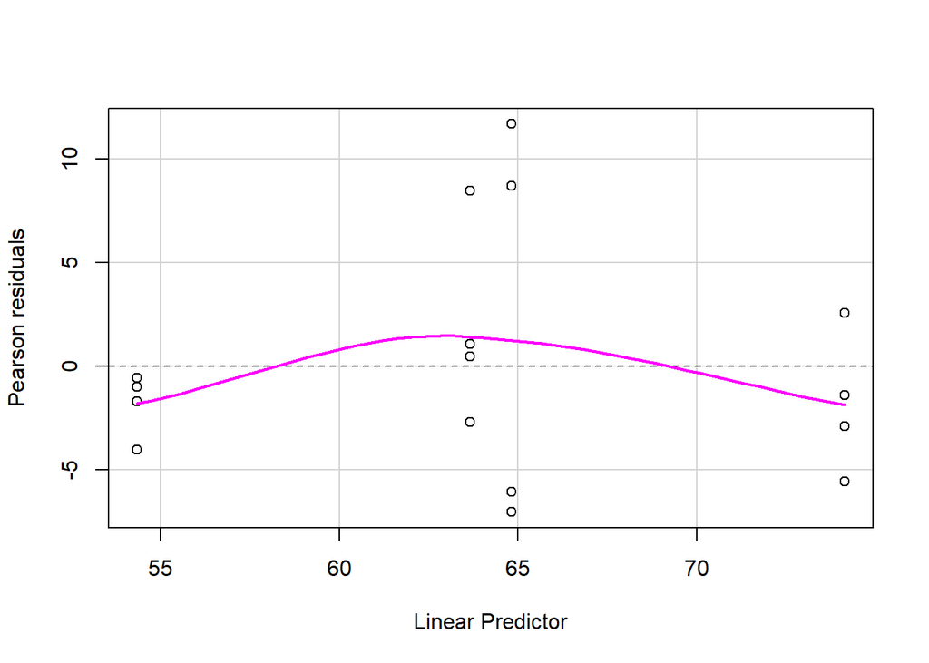

```r
residualPlot(mog)
```

Comprovem que no fa falta la interacció.

```r
mog_int <- glm(OVELLA ~ TERMIC * CaCl2, family = gaussian, dd)
anova(mog_int, mog)
```

```
## Analysis of Deviance Table
##
## Model 1: OVELLA ~ TERMIC * CaCl2
## Model 2: OVELLA ~ TERMIC + CaCl2
##   Resid. Df Resid. Dev Df Deviance      F Pr(>F)
## 1        12     395.33
## 2        13     448.53 -1  -53.199 1.6148 0.2279
```

### Link en el model additiu

Comprovem que canviant el link, el model no ajusta igual (ja que no és factorial). Per exemple passem del `link=identity` al `link="1/mu^2"`

Models additius

```r
mog_inv2 <- glm(OVELLA ~ TERMIC + CaCl2, family=gaussian(link="1/mu^2"), dd)
```

Estimació dels valors esperats marginals, emmeans dels 4 tractaments. Canvien les estimacions al canviar el link.

```r
(emmgll <- emmeans(mog,     ~ TERMIC*CaCl2, type="response"))
```

```
##  TERMIC        CaCl2 emmean   SE df lower.CL upper.CL
##  crua          amb     54.3 2.54 13     48.9     59.8
##  pasteuritzada amb     63.7 2.54 13     58.2     69.2
##  crua          sense   64.8 2.54 13     59.3     70.3
##  pasteuritzada sense   74.1 2.54 13     68.6     79.6
##
## Confidence level used: 0.95
```

```r
(emmglr <- emmeans(mog_inv2,~ TERMIC*CaCl2, type="response"))
```

```
##  TERMIC        CaCl2 response   SE df lower.CL upper.CL
##  crua          amb       56.3 2.33 13     51.9     62.2
##  pasteuritzada amb       62.7 2.76 13     57.5     69.7
##  crua          sense     64.1 2.81 13     58.7     71.2
##  pasteuritzada sense     74.0 3.02 13     68.2     81.5
##
## Confidence level used: 0.95
## Intervals are back-transformed from the 1/mu^2 scale
```

Comparem els residus.

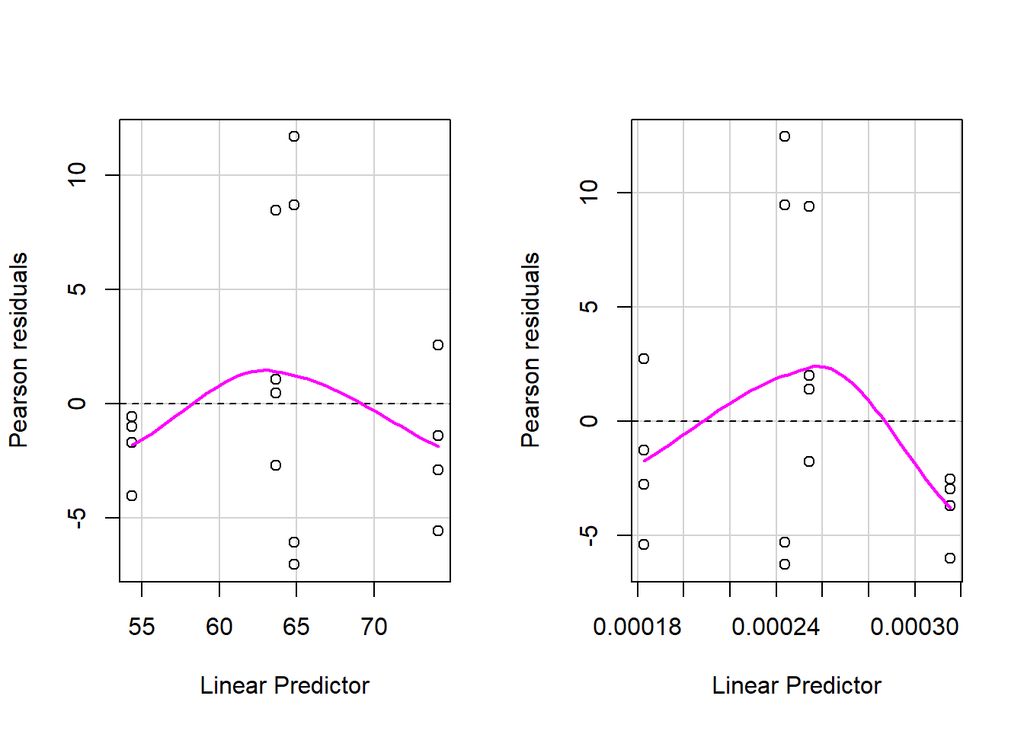

```r
par(mfrow=c(1,2))
residualPlot(mog)
residualPlot(mog_inv2)
```

Fa falta la interacció amb el nou link?

```r
mog_inv2_int <- glm(OVELLA~TERMIC*CaCl2, family=gaussian(link="1/mu^2"),dd)
anova(mog_inv2_int,mog_inv2)
```

```
## Analysis of Deviance Table
##
## Model 1: OVELLA ~ TERMIC * CaCl2
## Model 2: OVELLA ~ TERMIC + CaCl2
##   Resid. Df Resid. Dev Df Deviance      F  Pr(>F)
## 1        12     395.33
## 2        13     521.53 -1   -126.2 3.8306 0.07399 .
## ---
## Signif. codes:  0 '***' 0.001 '**' 0.01 '*' 0.05 '.' 0.1 ' ' 1
```

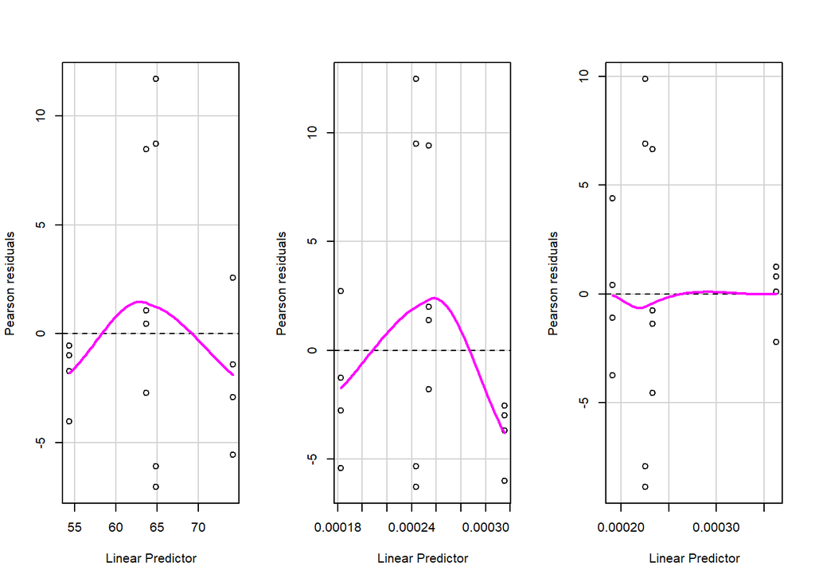

```r
par(mfrow=c(1,3))
residualPlot(mog)
residualPlot(mog_inv2)
residualPlot(mog_inv2_int)
```

### Familia en el model additiu

Canviar la família pot afectar a la homoscedasticitat. Per exemple passem de la família Gaussiana a la Inversa Gaussiana amb el link identitat.

```r
mog_iga <- glm(OVELLA ~ TERMIC + CaCl2,
               family=inverse.gaussian(link=identity), dd)
```

#### Validació

**Gràfic de residus**

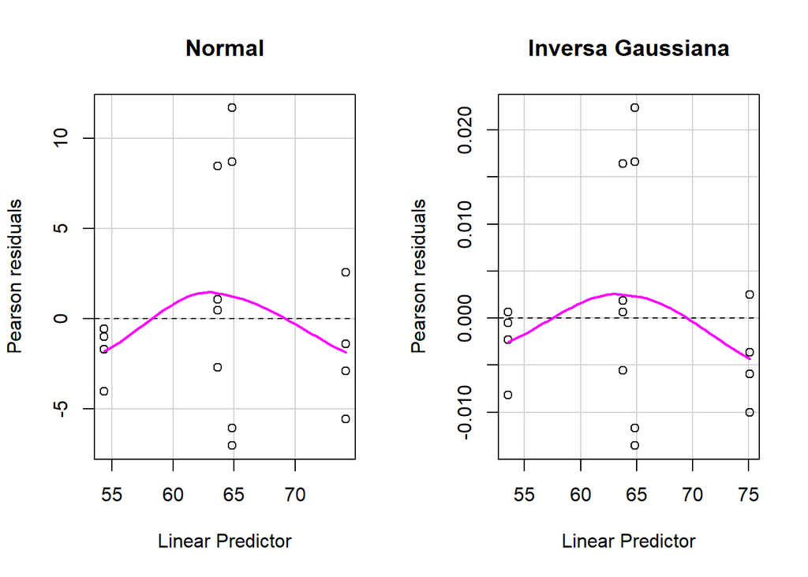

```r
par(mfrow=c(1,2))
residualPlot(mog,     main = "Normal")
residualPlot(mog_iga, main = "Inversa Gaussiana")
```

**Homoscedasticitat**

En els dos casos, hi ha diferències significatives entre nivells en cap de les 2 families.

```r
# Nivells i residus
dd$levels  <- factor(paste0(dd$TERMIC,'-',dd$CaCl2))
dd$res_nor <- resid(mog)
dd$res_iga <- resid(mog_iga)

# Variancies
with(dd,tapply(res_nor, levels, var))
```

```
##            crua-amb          crua-sense   pasteuritzada-amb pasteuritzada-sense
##            2.367583           95.384542           22.489550           11.534956
```

```r
with(dd,tapply(res_iga, levels, var)) * 10^4
```

```
##            crua-amb          crua-sense   pasteuritzada-amb pasteuritzada-sense
##           0.1639677           3.3390773           0.7912938           0.2910471
```

```r
# test var
leveneTest(res_nor ~ levels, dd)
```

```
## Levene's Test for Homogeneity of Variance (center = median)
##       Df F value   Pr(>F)
## group  3   8.529 0.002646 **
##       12
## ---
## Signif. codes:  0 '***' 0.001 '**' 0.01 '*' 0.05 '.' 0.1 ' ' 1
```

```r
leveneTest(res_iga ~ levels, dd)
```

```
## Levene's Test for Homogeneity of Variance (center = median)
##       Df F value   Pr(>F)
## group  3  8.5974 0.002563 **
##       12
## ---
## Signif. codes:  0 '***' 0.001 '**' 0.01 '*' 0.05 '.' 0.1 ' ' 1
```